# Investigating Game Statistics as Indicators of NBA Player Position

## Fall 2024 Data Science Project

David Chen, Chow-Fong Kust, Ashwin Sawant, Ze-wen Yu

## Contributions

David Chen (sections A, B, C, D, E, F, G, H). Overall, I collaborated with the team on all sections of the project. However, I mainly came up with the idea of the project, handled situations with players playing for multiple teams, conducted the anova test in part C, wrote parts of the documentation including the introduction, and published our project.

Chow-Fong Kust: (sections A, B, C, D, E, F, G) I contributed to all parts of the project but my main contributions were in the Data Exploration and Summary statistics, ML Algorithm Design/Development, Conclusion, and Final Tutorial Report Creation.

Ashwin Sawant: (sections B, C, D, E, F, G) I worked on some of the Data Exploration/Summary Statistics, and I mainly handled the design, training and evaluation of the ML algorithm with our training data.

Ze-wen Yu: (sections A, C, F, G, H) Found the original dataset on Kaggle along with presenting the smaller intricate parts of the basketball positions. I mostly handled creating parts of the final report and analyzing our models.

## 1. Introduction

As avid NBA fans, our group has watched many regular season games over the past few years. During these games, we have noticed that announcers and fans have talked a lot about the evolution of the game. Head coaches, fans, and scouts alike have begun to rely a lot on statistics to make judgements about specific players. Also, in recent years, the game itself has evolved into a “positionless” game, meaning that each player must be versatile enough to fulfill the duties typically associated with each of the different basketball positions.

Thus, the question our group is investigating is:

How are the game statistics of a player indicative of the role that they play on the team?

[figure not shown]

Additional reading from the NBA: https://jr.nba.com/basketball-positions/

## 2. Data Curation

```python
import pandas as pd
from datetime import datetime
import matplotlib.pyplot as plt
import seaborn as sns
import scipy.stats as stats
from collections import defaultdict
import numpy as np
```

The first step in our process was to find data related to NBA players, their roles, and their game statistics. Luckily, Kaggle had a plethora of datasets to choose from with the exact data that we needed. We chose to use the 2023-2024 NBA Player Stats.

We downloaded the data from Kaggle: Vinco, V. (2024, August). 2023-2024 NBA Player Stats. Kaggle. https://www.kaggle.com/datasets/vivovinco/2023-2024-nba-player-stats?resource=download

and obtained the file:

regular_season_2023-24.csv: This database contains 735 rows and 30 columns that contain information such as player id, name, position, age, team, and game statistics.

We then use Pandas to bring the data in and store it in a dataframe:

```python
player_info_df = pd.read_csv("regular_season_2023-24.csv", encoding='ISO-8859-1', delimiter=";")
player_info_df
```

|  | Rk | Player | Pos | Age | Tm | G | GS | MP | FG | FGA | ... | FT% | ORB | DRB | TRB | AST | STL | BLK | TOV | PF | PTS |
| --- | --- | --- | --- | --- | --- | --- | --- | --- | --- | --- | --- | --- | --- | --- | --- | --- | --- | --- | --- | --- | --- |
| 0 | 1 | Precious Achiuwa | PF-C | 24 | TOT | 74 | 18 | 21.9 | 3.2 | 6.3 | ... | 0.616 | 2.6 | 4.0 | 6.6 | 1.3 | 0.6 | 0.9 | 1.1 | 1.9 | 7.6 |
| 1 | 1 | Precious Achiuwa | C | 24 | TOR | 25 | 0 | 17.5 | 3.1 | 6.8 | ... | 0.571 | 2.0 | 3.4 | 5.4 | 1.8 | 0.6 | 0.5 | 1.2 | 1.6 | 7.7 |
| 2 | 1 | Precious Achiuwa | PF | 24 | NYK | 49 | 18 | 24.2 | 3.2 | 6.1 | ... | 0.643 | 2.9 | 4.3 | 7.2 | 1.1 | 0.6 | 1.1 | 1.1 | 2.1 | 7.6 |
| 3 | 2 | Bam Adebayo | C | 26 | MIA | 71 | 71 | 34.0 | 7.5 | 14.3 | ... | 0.755 | 2.2 | 8.1 | 10.4 | 3.9 | 1.1 | 0.9 | 2.3 | 2.2 | 19.3 |
| 4 | 3 | Ochai Agbaji | SG | 23 | TOT | 78 | 28 | 21.0 | 2.3 | 5.6 | ... | 0.661 | 0.9 | 1.8 | 2.8 | 1.1 | 0.6 | 0.6 | 0.8 | 1.5 | 5.8 |
| ... | ... | ... | ... | ... | ... | ... | ... | ... | ... | ... | ... | ... | ... | ... | ... | ... | ... | ... | ... | ... | ... |
| 730 | 568 | Thaddeus Young | PF | 35 | PHO | 10 | 0 | 8.9 | 1.1 | 2.1 | ... | 0.333 | 1.7 | 1.1 | 2.8 | 0.7 | 0.5 | 0.2 | 0.4 | 1.1 | 2.3 |
| 731 | 569 | Trae Young | PG | 25 | ATL | 54 | 54 | 36.0 | 8.0 | 18.7 | ... | 0.855 | 0.4 | 2.3 | 2.8 | 10.8 | 1.3 | 0.2 | 4.4 | 2.0 | 25.7 |
| 732 | 570 | Omer Yurtseven | C | 25 | UTA | 48 | 12 | 11.4 | 2.1 | 3.8 | ... | 0.679 | 1.5 | 2.8 | 4.3 | 0.6 | 0.2 | 0.4 | 0.8 | 1.1 | 4.6 |
| 733 | 571 | Cody Zeller | C | 31 | NOP | 43 | 0 | 7.4 | 0.6 | 1.4 | ... | 0.605 | 1.1 | 1.5 | 2.6 | 0.9 | 0.2 | 0.1 | 0.4 | 1.0 | 1.8 |
| 734 | 572 | Ivica Zubac | C | 26 | LAC | 68 | 68 | 26.4 | 5.0 | 7.6 | ... | 0.723 | 2.9 | 6.3 | 9.2 | 1.4 | 0.3 | 1.2 | 1.2 | 2.6 | 11.7 |

735 rows × 30 columns

The data consists of samples with the following features [1]:  
Rk : Rank  
Player : Player's name  
Pos : Position  
Age : Player's age  
Tm : Team  
G : Games played  
GS : Games started  
MP : Minutes played per game  
FG : Field goals per game  
FGA : Field goal attempts per game  
FG% : Field goal percentage  
3P : 3-point field goals per game  
3PA : 3-point field goal attempts per game  
3P% : 3-point field goal percentage  
2P : 2-point field goals per game  
2PA : 2-point field goal attempts per game  
2P% : 2-point field goal percentage  
eFG% : Effective field goal percentage  
FT : Free throws per game  
FTA : Free throw attempts per game  
FT% : Free throw percentage  
ORB : Offensive rebounds per game  
DRB : Defensive rebounds per game  
TRB : Total rebounds per game  
AST : Assists per game  
STL : Steals per game  
BLK : Blocks per game  
TOV : Turnovers per game  
PF : Personal fouls per game  
PTS : Points per game

[1] For additional reading on basketball statistics and common trends: https://hoopstudent.com/basketball-statistics-explanation/

Check for Missing Data. We can see that there is none.

```python
for column in player_info_df.columns:
    print(f"Column {column} has {player_info_df[column].isna().sum()} null values")
```

```
Column Rk has 0 null values
Column Player has 0 null values
Column Pos has 0 null values
Column Age has 0 null values
Column Tm has 0 null values
Column G has 0 null values
Column GS has 0 null values
Column MP has 0 null values
Column FG has 0 null values
Column FGA has 0 null values
Column FG% has 0 null values
Column 3P has 0 null values
Column 3PA has 0 null values
Column 3P% has 0 null values
Column 2P has 0 null values
Column 2PA has 0 null values
Column 2P% has 0 null values
Column eFG% has 0 null values
Column FT has 0 null values
Column FTA has 0 null values
Column FT% has 0 null values
Column ORB has 0 null values
Column DRB has 0 null values
Column TRB has 0 null values
Column AST has 0 null values
Column STL has 0 null values
Column BLK has 0 null values
Column TOV has 0 null values
Column PF has 0 null values
Column PTS has 0 null values
```

To clean up the data, we converted the data to the appropriate types, and checked for null values. The data didn’t contain null values, but it did contain multiple rows for the same player, in cases where players played for multiple teams in the same season. In these cases, players had TOT (total) for their cumulative stats. We decided to keep these stats for these players rather than keeping the data from the stints with each of the teams.

Convert string data into necessary numerical data

```python
# Convert necessary columns from strings to integers
cols_to_convert_int = ["Rk", "Age", "G", "GS"]
for col in cols_to_convert_int:
    player_info_df[col] = player_info_df[col].apply(lambda x: int(x))


# Convert necessary columns from strings to floating point numbers
cols_to_convert_float = ["MP", "FG", "FGA", "FG%", "3P", "3PA", "3P%", "2P", "2PA", "2P%", "eFG%", "FT", "FTA", "FT%", "ORB", "DRB", "TRB", "AST", "STL", "BLK", "TOV", "PF", "PTS"]
for col in cols_to_convert_float:
    player_info_df[col] = player_info_df[col].apply(lambda x: float(x))
```

Our data has duplicate entries for players that were on different teams, where each entry corresponds to the data on their time with each team. Every player with duplicate entries also has an entry with TOT as the team name, representing the aggregated data from their time with each team. Since we're only concerned with individual player performance, we can drop the duplicate entries for players, and only keep the aggregate data.

```python
player_info = player_info_df.drop_duplicates(["Rk"])
player_info
```

|  | Rk | Player | Pos | Age | Tm | G | GS | MP | FG | FGA | ... | FT% | ORB | DRB | TRB | AST | STL | BLK | TOV | PF | PTS |
| --- | --- | --- | --- | --- | --- | --- | --- | --- | --- | --- | --- | --- | --- | --- | --- | --- | --- | --- | --- | --- | --- |
| 0 | 1 | Precious Achiuwa | PF-C | 24 | TOT | 74 | 18 | 21.9 | 3.2 | 6.3 | ... | 0.616 | 2.6 | 4.0 | 6.6 | 1.3 | 0.6 | 0.9 | 1.1 | 1.9 | 7.6 |
| 3 | 2 | Bam Adebayo | C | 26 | MIA | 71 | 71 | 34.0 | 7.5 | 14.3 | ... | 0.755 | 2.2 | 8.1 | 10.4 | 3.9 | 1.1 | 0.9 | 2.3 | 2.2 | 19.3 |
| 4 | 3 | Ochai Agbaji | SG | 23 | TOT | 78 | 28 | 21.0 | 2.3 | 5.6 | ... | 0.661 | 0.9 | 1.8 | 2.8 | 1.1 | 0.6 | 0.6 | 0.8 | 1.5 | 5.8 |
| 7 | 4 | Santi Aldama | PF | 23 | MEM | 61 | 35 | 26.5 | 4.0 | 9.3 | ... | 0.621 | 1.2 | 4.6 | 5.8 | 2.3 | 0.7 | 0.9 | 1.1 | 1.5 | 10.7 |
| 8 | 5 | Nickeil Alexander-Walker | SG | 25 | MIN | 82 | 20 | 23.4 | 2.9 | 6.6 | ... | 0.800 | 0.4 | 1.6 | 2.0 | 2.5 | 0.8 | 0.5 | 0.9 | 1.7 | 8.0 |
| ... | ... | ... | ... | ... | ... | ... | ... | ... | ... | ... | ... | ... | ... | ... | ... | ... | ... | ... | ... | ... | ... |
| 728 | 568 | Thaddeus Young | PF | 35 | TOT | 33 | 6 | 13.3 | 2.0 | 3.3 | ... | 0.400 | 1.4 | 1.7 | 3.1 | 1.7 | 0.7 | 0.2 | 0.5 | 1.5 | 4.2 |
| 731 | 569 | Trae Young | PG | 25 | ATL | 54 | 54 | 36.0 | 8.0 | 18.7 | ... | 0.855 | 0.4 | 2.3 | 2.8 | 10.8 | 1.3 | 0.2 | 4.4 | 2.0 | 25.7 |
| 732 | 570 | Omer Yurtseven | C | 25 | UTA | 48 | 12 | 11.4 | 2.1 | 3.8 | ... | 0.679 | 1.5 | 2.8 | 4.3 | 0.6 | 0.2 | 0.4 | 0.8 | 1.1 | 4.6 |
| 733 | 571 | Cody Zeller | C | 31 | NOP | 43 | 0 | 7.4 | 0.6 | 1.4 | ... | 0.605 | 1.1 | 1.5 | 2.6 | 0.9 | 0.2 | 0.1 | 0.4 | 1.0 | 1.8 |
| 734 | 572 | Ivica Zubac | C | 26 | LAC | 68 | 68 | 26.4 | 5.0 | 7.6 | ... | 0.723 | 2.9 | 6.3 | 9.2 | 1.4 | 0.3 | 1.2 | 1.2 | 2.6 | 11.7 |

572 rows × 30 columns

## 3. Exploratory Data Analysis

### Statistical Method #1: Correlation Test

Let's see if there's any correlation between Steals, Blocks, and Personal Fouls

```python
corr_columns = ["STL", "BLK", "PF"]
corr_matrix = player_info_df[corr_columns].corr(method="pearson")
corr_matrix
```

|  | STL | BLK | PF |
| --- | --- | --- | --- |
| STL | 1.000000 | 0.360813 | 0.607053 |
| BLK | 0.360813 | 1.000000 | 0.558892 |
| PF | 0.607053 | 0.558892 | 1.000000 |

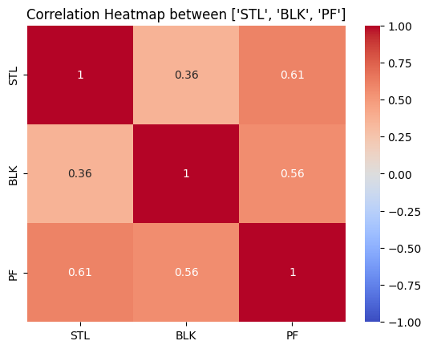

```python
plt.figure()
sns.heatmap(corr_matrix, annot=True, vmin=-1, vmax=1, cmap='coolwarm')
plt.title(f"Correlation Heatmap between {corr_columns}")

plt.show()
```

### Statistical Method 2: Observing Distribution for Outliers

Let's examine if there are any outliers in average total rebounds per game for players by examining the distribution in a box plot

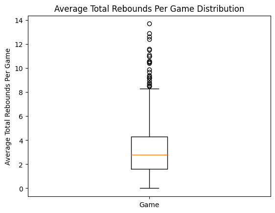

```python
plt.boxplot(player_info_df['TRB'].dropna(), tick_labels=["Game"])
plt.ylabel('Average Total Rebounds Per Game')
plt.title("Average Total Rebounds Per Game Distribution")
plt.show()
```

```python
df = player_info_df
Q1 = df['TRB'].quantile(0.25)
Q3 = df['TRB'].quantile(0.75)
IQR = Q3 - Q1

lower = Q1 - 1.5 * IQR
upper = Q3 + 1.5 * IQR

outliers = df[(df['TRB'] < lower) | (df['TRB'] > upper)]
num_outliers = outliers.shape[0]
print(f"Number of Outliers: {num_outliers}")
```

```
Number of Outliers: 27
```

Looking at the distribution for average total rebounds per game we see that most of the values fall between 0 and 8 with a median of around 3 average total rebounds per game. However, there are many outliers in this dataset where certain individuals get much higher total rebounds per game compared to the median. This is likely due to multiple factors such as average playtime per game as players who are on the court more have more opportunities to get rebounds or height of the players as taller individuals have an advantage over others in getting the rebound after a shot.

### Statistical Method 3: ANOVA Test

We want to know if specific basketball positions have an effect on the mean points per game. Since there are 5 groups of positions, we use an ANOVA test. Since some players played on different positions on different teams, we added the data for those players to the categories of each position they played for

For more on ANOVA tests read here: https://datatab.net/tutorial/anova

**Null hypothesis:** The position of a player has no effect on the mean points per game during the 2023-2024 regular season.  
**Alternative hypothesis:** The position of a player affects the mean points per game during the 2023-2024 regular season.

```python
grouped = player_info_df.groupby('Pos')
dfs = {name: group for name, group in grouped}

position_data = defaultdict(list)

for name, group in grouped:
    positions = name.split('-')

    for position in positions:
        position_data[position].append(group['PTS'].dropna().to_numpy())

for position, data in dfs.items():
    print(f"Position: {position}")
    display(data)

merged_positions_data = {pos: np.concatenate(data) for pos, data in position_data.items()}


print("Merged Positions Data:")
for position, data in merged_positions_data.items():
    print(f"Position: {position}")
    print(f"Data: {data}")
```

```
Position: C
```

|  | Rk | Player | Pos | Age | Tm | G | GS | MP | FG | FGA | ... | FT% | ORB | DRB | TRB | AST | STL | BLK | TOV | PF | PTS |
| --- | --- | --- | --- | --- | --- | --- | --- | --- | --- | --- | --- | --- | --- | --- | --- | --- | --- | --- | --- | --- | --- |
| 1 | 1 | Precious Achiuwa | C | 24 | TOR | 25 | 0 | 17.5 | 3.1 | 6.8 | ... | 0.571 | 2.0 | 3.4 | 5.4 | 1.8 | 0.6 | 0.5 | 1.2 | 1.6 | 7.7 |
| 3 | 2 | Bam Adebayo | C | 26 | MIA | 71 | 71 | 34.0 | 7.5 | 14.3 | ... | 0.755 | 2.2 | 8.1 | 10.4 | 3.9 | 1.1 | 0.9 | 2.3 | 2.2 | 19.3 |
| 10 | 7 | Jarrett Allen | C | 25 | CLE | 77 | 77 | 31.7 | 6.7 | 10.6 | ... | 0.742 | 3.2 | 7.4 | 10.5 | 2.7 | 0.7 | 1.1 | 1.6 | 1.9 | 16.5 |
| 22 | 17 | Deandre Ayton | C | 25 | POR | 55 | 55 | 32.4 | 7.8 | 13.6 | ... | 0.823 | 3.2 | 7.9 | 11.1 | 1.6 | 1.0 | 0.8 | 1.8 | 2.0 | 16.7 |
| 23 | 18 | Udoka Azubuike | C | 24 | PHO | 16 | 0 | 7.1 | 1.0 | 1.4 | ... | 0.231 | 0.7 | 1.3 | 2.0 | 0.2 | 0.1 | 0.4 | 0.3 | 1.1 | 2.2 |
| ... | ... | ... | ... | ... | ... | ... | ... | ... | ... | ... | ... | ... | ... | ... | ... | ... | ... | ... | ... | ... | ... |
| 712 | 557 | Robert Williams | C | 26 | POR | 6 | 0 | 19.8 | 2.8 | 4.3 | ... | 0.778 | 1.8 | 4.5 | 6.3 | 0.8 | 1.2 | 1.2 | 1.2 | 2.8 | 6.8 |
| 722 | 564 | James Wiseman | C | 22 | DET | 63 | 6 | 17.3 | 3.0 | 4.8 | ... | 0.706 | 1.7 | 3.6 | 5.3 | 0.9 | 0.2 | 0.6 | 1.0 | 2.2 | 7.1 |
| 732 | 570 | Omer Yurtseven | C | 25 | UTA | 48 | 12 | 11.4 | 2.1 | 3.8 | ... | 0.679 | 1.5 | 2.8 | 4.3 | 0.6 | 0.2 | 0.4 | 0.8 | 1.1 | 4.6 |
| 733 | 571 | Cody Zeller | C | 31 | NOP | 43 | 0 | 7.4 | 0.6 | 1.4 | ... | 0.605 | 1.1 | 1.5 | 2.6 | 0.9 | 0.2 | 0.1 | 0.4 | 1.0 | 1.8 |
| 734 | 572 | Ivica Zubac | C | 26 | LAC | 68 | 68 | 26.4 | 5.0 | 7.6 | ... | 0.723 | 2.9 | 6.3 | 9.2 | 1.4 | 0.3 | 1.2 | 1.2 | 2.6 | 11.7 |

119 rows × 30 columns

```
Position: C-PF
```

|  | Rk | Player | Pos | Age | Tm | G | GS | MP | FG | FGA | ... | FT% | ORB | DRB | TRB | AST | STL | BLK | TOV | PF | PTS |
| --- | --- | --- | --- | --- | --- | --- | --- | --- | --- | --- | --- | --- | --- | --- | --- | --- | --- | --- | --- | --- | --- |
| 215 | 161 | Daniel Gafford | C-PF | 25 | TOT | 74 | 66 | 24.5 | 4.7 | 6.5 | ... | 0.674 | 2.6 | 5.0 | 7.6 | 1.6 | 0.9 | 2.1 | 1.0 | 3.1 | 11.0 |
| 297 | 224 | Richaun Holmes | C-PF | 30 | TOT | 40 | 10 | 13.9 | 2.1 | 3.7 | ... | 0.723 | 1.8 | 2.8 | 4.6 | 0.6 | 0.3 | 0.5 | 0.6 | 1.9 | 5.0 |
| 645 | 502 | Xavier Tillman Sr. | C-PF | 25 | TOT | 54 | 15 | 18.0 | 2.2 | 5.2 | ... | 0.440 | 1.3 | 2.6 | 3.9 | 1.4 | 0.9 | 0.8 | 0.6 | 1.4 | 5.3 |

3 rows × 30 columns

```
Position: PF
```

|  | Rk | Player | Pos | Age | Tm | G | GS | MP | FG | FGA | ... | FT% | ORB | DRB | TRB | AST | STL | BLK | TOV | PF | PTS |
| --- | --- | --- | --- | --- | --- | --- | --- | --- | --- | --- | --- | --- | --- | --- | --- | --- | --- | --- | --- | --- | --- |
| 2 | 1 | Precious Achiuwa | PF | 24 | NYK | 49 | 18 | 24.2 | 3.2 | 6.1 | ... | 0.643 | 2.9 | 4.3 | 7.2 | 1.1 | 0.6 | 1.1 | 1.1 | 2.1 | 7.6 |
| 7 | 4 | Santi Aldama | PF | 23 | MEM | 61 | 35 | 26.5 | 4.0 | 9.3 | ... | 0.621 | 1.2 | 4.6 | 5.8 | 2.3 | 0.7 | 0.9 | 1.1 | 1.5 | 10.7 |
| 13 | 10 | Kyle Anderson | PF | 30 | MIN | 79 | 10 | 22.6 | 2.5 | 5.5 | ... | 0.708 | 0.8 | 2.7 | 3.5 | 4.2 | 0.9 | 0.6 | 1.2 | 1.6 | 6.4 |
| 14 | 11 | Giannis Antetokounmpo | PF | 29 | MIL | 73 | 73 | 35.2 | 11.5 | 18.8 | ... | 0.657 | 2.7 | 8.8 | 11.5 | 6.5 | 1.2 | 1.1 | 3.4 | 2.9 | 30.4 |
| 15 | 12 | Thanasis Antetokounmpo | PF | 31 | MIL | 34 | 0 | 4.6 | 0.5 | 0.9 | ... | 0.000 | 0.2 | 0.2 | 0.4 | 0.5 | 0.2 | 0.1 | 0.4 | 0.7 | 0.9 |
| ... | ... | ... | ... | ... | ... | ... | ... | ... | ... | ... | ... | ... | ... | ... | ... | ... | ... | ... | ... | ... | ... |
| 717 | 562 | Jalen Wilson | PF | 23 | BRK | 43 | 3 | 15.4 | 1.8 | 4.2 | ... | 0.826 | 1.1 | 2.0 | 3.0 | 1.0 | 0.3 | 0.1 | 0.4 | 1.1 | 5.0 |
| 724 | 566 | Christian Wood | PF | 28 | LAL | 50 | 1 | 17.4 | 2.5 | 5.3 | ... | 0.702 | 0.8 | 4.3 | 5.1 | 1.0 | 0.3 | 0.7 | 1.0 | 1.4 | 6.9 |
| 728 | 568 | Thaddeus Young | PF | 35 | TOT | 33 | 6 | 13.3 | 2.0 | 3.3 | ... | 0.400 | 1.4 | 1.7 | 3.1 | 1.7 | 0.7 | 0.2 | 0.5 | 1.5 | 4.2 |
| 729 | 568 | Thaddeus Young | PF | 35 | TOR | 23 | 6 | 15.2 | 2.3 | 3.8 | ... | 0.417 | 1.3 | 2.0 | 3.3 | 2.2 | 0.8 | 0.1 | 0.5 | 1.7 | 5.0 |
| 730 | 568 | Thaddeus Young | PF | 35 | PHO | 10 | 0 | 8.9 | 1.1 | 2.1 | ... | 0.333 | 1.7 | 1.1 | 2.8 | 0.7 | 0.5 | 0.2 | 0.4 | 1.1 | 2.3 |

147 rows × 30 columns

```
Position: PF-C
```

|  | Rk | Player | Pos | Age | Tm | G | GS | MP | FG | FGA | ... | FT% | ORB | DRB | TRB | AST | STL | BLK | TOV | PF | PTS |
| --- | --- | --- | --- | --- | --- | --- | --- | --- | --- | --- | --- | --- | --- | --- | --- | --- | --- | --- | --- | --- | --- |
| 0 | 1 | Precious Achiuwa | PF-C | 24 | TOT | 74 | 18 | 21.9 | 3.2 | 6.3 | ... | 0.616 | 2.6 | 4.0 | 6.6 | 1.3 | 0.6 | 0.9 | 1.1 | 1.9 | 7.6 |

1 rows × 30 columns

```
Position: PF-SF
```

|  | Rk | Player | Pos | Age | Tm | G | GS | MP | FG | FGA | ... | FT% | ORB | DRB | TRB | AST | STL | BLK | TOV | PF | PTS |
| --- | --- | --- | --- | --- | --- | --- | --- | --- | --- | --- | --- | --- | --- | --- | --- | --- | --- | --- | --- | --- | --- |
| 218 | 162 | Danilo Gallinari | PF-SF | 35 | TOT | 49 | 0 | 12.9 | 1.7 | 3.9 | ... | 0.857 | 0.4 | 1.8 | 2.2 | 1.1 | 0.3 | 0.1 | 0.5 | 1.0 | 5.7 |

1 rows × 30 columns

```
Position: PG
```

|  | Rk | Player | Pos | Age | Tm | G | GS | MP | FG | FGA | ... | FT% | ORB | DRB | TRB | AST | STL | BLK | TOV | PF | PTS |
| --- | --- | --- | --- | --- | --- | --- | --- | --- | --- | --- | --- | --- | --- | --- | --- | --- | --- | --- | --- | --- | --- |
| 12 | 9 | Jose Alvarado | PG | 25 | NOP | 56 | 0 | 18.4 | 2.5 | 6.2 | ... | 0.673 | 0.4 | 1.8 | 2.3 | 2.1 | 1.1 | 0.3 | 0.7 | 1.6 | 7.1 |
| 16 | 13 | Cole Anthony | PG | 23 | ORL | 81 | 0 | 22.4 | 4.1 | 9.4 | ... | 0.826 | 0.8 | 3.0 | 3.8 | 2.9 | 0.8 | 0.5 | 1.6 | 2.2 | 11.6 |
| 20 | 15 | Ryan Arcidiacono | PG | 29 | NYK | 20 | 0 | 2.3 | 0.0 | 0.3 | ... | 0.000 | 0.0 | 0.4 | 0.4 | 0.2 | 0.1 | 0.0 | 0.1 | 0.3 | 0.0 |
| 28 | 21 | Amari Bailey | PG | 19 | CHO | 10 | 0 | 6.5 | 0.8 | 2.4 | ... | 0.857 | 0.6 | 0.3 | 0.9 | 0.7 | 0.3 | 0.0 | 0.4 | 0.2 | 2.3 |
| 30 | 23 | LaMelo Ball | PG | 22 | CHO | 22 | 22 | 32.3 | 8.3 | 19.2 | ... | 0.865 | 1.3 | 3.8 | 5.1 | 8.0 | 1.8 | 0.2 | 3.8 | 3.6 | 23.9 |
| ... | ... | ... | ... | ... | ... | ... | ... | ... | ... | ... | ... | ... | ... | ... | ... | ... | ... | ... | ... | ... | ... |
| 701 | 548 | Brandon Williams | PG | 24 | DAL | 17 | 0 | 6.6 | 1.2 | 3.2 | ... | 0.647 | 0.2 | 0.5 | 0.8 | 1.0 | 0.1 | 0.1 | 0.4 | 0.2 | 3.2 |
| 725 | 567 | Delon Wright | PG | 31 | TOT | 47 | 1 | 15.8 | 1.6 | 4.0 | ... | 0.822 | 0.4 | 1.4 | 1.8 | 2.5 | 1.1 | 0.2 | 0.3 | 0.7 | 4.5 |
| 726 | 567 | Delon Wright | PG | 31 | WAS | 33 | 0 | 13.8 | 1.5 | 3.7 | ... | 0.828 | 0.4 | 1.4 | 1.8 | 2.5 | 1.1 | 0.2 | 0.3 | 0.7 | 4.1 |
| 727 | 567 | Delon Wright | PG | 31 | MIA | 14 | 1 | 20.4 | 1.9 | 4.7 | ... | 0.813 | 0.4 | 1.5 | 1.9 | 2.6 | 1.4 | 0.2 | 0.2 | 0.7 | 5.4 |
| 731 | 569 | Trae Young | PG | 25 | ATL | 54 | 54 | 36.0 | 8.0 | 18.7 | ... | 0.855 | 0.4 | 2.3 | 2.8 | 10.8 | 1.3 | 0.2 | 4.4 | 2.0 | 25.7 |

147 rows × 30 columns

```
Position: PG-SG
```

|  | Rk | Player | Pos | Age | Tm | G | GS | MP | FG | FGA | ... | FT% | ORB | DRB | TRB | AST | STL | BLK | TOV | PF | PTS |
| --- | --- | --- | --- | --- | --- | --- | --- | --- | --- | --- | --- | --- | --- | --- | --- | --- | --- | --- | --- | --- | --- |
| 97 | 68 | Bruce Brown | PG-SG | 27 | TOT | 67 | 44 | 27.9 | 4.1 | 8.7 | ... | 0.824 | 0.8 | 3.4 | 4.2 | 2.9 | 0.9 | 0.3 | 1.3 | 2.2 | 10.8 |
| 416 | 325 | Skylar Mays | PG-SG | 26 | TOT | 38 | 5 | 11.4 | 1.7 | 4.2 | ... | 0.765 | 0.3 | 0.9 | 1.1 | 2.2 | 0.6 | 0.1 | 0.5 | 0.7 | 4.1 |
| 545 | 420 | Immanuel Quickley | PG-SG | 24 | TOT | 68 | 38 | 29.2 | 5.7 | 13.1 | ... | 0.853 | 0.3 | 3.6 | 3.8 | 4.9 | 0.7 | 0.1 | 1.5 | 1.8 | 17.0 |
| 571 | 440 | Terry Rozier | PG-SG | 29 | TOT | 61 | 60 | 33.4 | 7.2 | 16.4 | ... | 0.869 | 0.6 | 3.5 | 4.0 | 5.6 | 1.0 | 0.3 | 1.7 | 1.7 | 19.8 |

4 rows × 30 columns

```
Position: SF
```

|  | Rk | Player | Pos | Age | Tm | G | GS | MP | FG | FGA | ... | FT% | ORB | DRB | TRB | AST | STL | BLK | TOV | PF | PTS |
| --- | --- | --- | --- | --- | --- | --- | --- | --- | --- | --- | --- | --- | --- | --- | --- | --- | --- | --- | --- | --- | --- |
| 11 | 8 | Timmy Allen | SF | 24 | MEM | 5 | 0 | 25.0 | 1.2 | 4.6 | ... | 0.500 | 0.8 | 2.6 | 3.4 | 1.0 | 0.8 | 0.0 | 0.4 | 3.6 | 2.6 |
| 17 | 14 | OG Anunoby | SF | 26 | TOT | 50 | 50 | 34.0 | 5.6 | 11.5 | ... | 0.753 | 0.9 | 3.2 | 4.2 | 2.1 | 1.4 | 0.7 | 1.6 | 2.4 | 14.7 |
| 18 | 14 | OG Anunoby | SF | 26 | TOR | 27 | 27 | 33.3 | 5.8 | 11.9 | ... | 0.717 | 0.9 | 3.0 | 3.9 | 2.7 | 1.0 | 0.5 | 1.6 | 2.3 | 15.1 |
| 19 | 14 | OG Anunoby | SF | 26 | NYK | 23 | 23 | 34.9 | 5.4 | 11.1 | ... | 0.791 | 1.0 | 3.4 | 4.4 | 1.5 | 1.7 | 1.0 | 1.7 | 2.5 | 14.1 |
| 21 | 16 | Deni Avdija | SF | 23 | WAS | 75 | 75 | 30.1 | 5.4 | 10.7 | ... | 0.740 | 1.1 | 6.1 | 7.2 | 3.8 | 0.8 | 0.5 | 2.1 | 2.5 | 14.7 |
| ... | ... | ... | ... | ... | ... | ... | ... | ... | ... | ... | ... | ... | ... | ... | ... | ... | ... | ... | ... | ... | ... |
| 714 | 559 | Ziaire Williams | SF | 22 | MEM | 51 | 15 | 20.4 | 2.9 | 7.4 | ... | 0.827 | 0.7 | 2.8 | 3.5 | 1.5 | 0.7 | 0.2 | 1.3 | 1.7 | 8.2 |
| 718 | 563 | Dylan Windler | SF | 27 | TOT | 17 | 0 | 6.4 | 0.9 | 1.8 | ... | 0.000 | 0.2 | 0.8 | 0.9 | 0.6 | 0.1 | 0.0 | 0.1 | 0.4 | 2.5 |
| 719 | 563 | Dylan Windler | SF | 27 | NYK | 3 | 0 | 2.3 | 0.3 | 0.7 | ... | 0.000 | 0.0 | 0.3 | 0.3 | 0.3 | 0.0 | 0.0 | 0.0 | 0.3 | 1.0 |
| 720 | 563 | Dylan Windler | SF | 27 | LAL | 8 | 0 | 3.5 | 0.5 | 1.1 | ... | 0.000 | 0.0 | 0.4 | 0.4 | 0.8 | 0.0 | 0.0 | 0.0 | 0.3 | 1.5 |
| 721 | 563 | Dylan Windler | SF | 27 | ATL | 6 | 0 | 12.2 | 1.7 | 3.2 | ... | 0.000 | 0.5 | 1.5 | 2.0 | 0.5 | 0.3 | 0.0 | 0.3 | 0.5 | 4.7 |

155 rows × 30 columns

```
Position: SF-PF
```

|  | Rk | Player | Pos | Age | Tm | G | GS | MP | FG | FGA | ... | FT% | ORB | DRB | TRB | AST | STL | BLK | TOV | PF | PTS |
| --- | --- | --- | --- | --- | --- | --- | --- | --- | --- | --- | --- | --- | --- | --- | --- | --- | --- | --- | --- | --- | --- |
| 74 | 51 | Bojan Bogdanovi? | SF-PF | 34 | TOT | 57 | 27 | 25.9 | 5.4 | 11.9 | ... | 0.785 | 0.4 | 2.3 | 2.7 | 1.7 | 0.5 | 0.1 | 1.8 | 1.7 | 15.2 |
| 143 | 108 | Robert Covington | SF-PF | 33 | TOT | 29 | 6 | 16.8 | 1.5 | 3.4 | ... | 0.846 | 1.1 | 2.3 | 3.3 | 0.8 | 1.3 | 0.6 | 0.4 | 1.9 | 4.4 |

2 rows × 30 columns

```
Position: SF-SG
```

|  | Rk | Player | Pos | Age | Tm | G | GS | MP | FG | FGA | ... | FT% | ORB | DRB | TRB | AST | STL | BLK | TOV | PF | PTS |
| --- | --- | --- | --- | --- | --- | --- | --- | --- | --- | --- | --- | --- | --- | --- | --- | --- | --- | --- | --- | --- | --- |
| 288 | 217 | Buddy Hield | SF-SG | 31 | TOT | 84 | 42 | 25.7 | 4.4 | 10.1 | ... | 0.881 | 0.7 | 2.5 | 3.2 | 2.8 | 0.8 | 0.5 | 1.2 | 2.0 | 12.1 |

1 rows × 30 columns

```
Position: SG
```

|  | Rk | Player | Pos | Age | Tm | G | GS | MP | FG | FGA | ... | FT% | ORB | DRB | TRB | AST | STL | BLK | TOV | PF | PTS |
| --- | --- | --- | --- | --- | --- | --- | --- | --- | --- | --- | --- | --- | --- | --- | --- | --- | --- | --- | --- | --- | --- |
| 4 | 3 | Ochai Agbaji | SG | 23 | TOT | 78 | 28 | 21.0 | 2.3 | 5.6 | ... | 0.661 | 0.9 | 1.8 | 2.8 | 1.1 | 0.6 | 0.6 | 0.8 | 1.5 | 5.8 |
| 5 | 3 | Ochai Agbaji | SG | 23 | UTA | 51 | 10 | 19.7 | 2.1 | 4.9 | ... | 0.750 | 0.7 | 1.8 | 2.5 | 0.9 | 0.5 | 0.6 | 0.7 | 1.3 | 5.4 |
| 6 | 3 | Ochai Agbaji | SG | 23 | TOR | 27 | 18 | 23.6 | 2.7 | 6.8 | ... | 0.611 | 1.4 | 1.9 | 3.3 | 1.3 | 0.7 | 0.6 | 1.1 | 1.9 | 6.7 |
| 8 | 5 | Nickeil Alexander-Walker | SG | 25 | MIN | 82 | 20 | 23.4 | 2.9 | 6.6 | ... | 0.800 | 0.4 | 1.6 | 2.0 | 2.5 | 0.8 | 0.5 | 0.9 | 1.7 | 8.0 |
| 9 | 6 | Grayson Allen | SG | 28 | PHO | 75 | 74 | 33.5 | 4.5 | 9.1 | ... | 0.878 | 0.6 | 3.3 | 3.9 | 3.0 | 0.9 | 0.6 | 1.3 | 2.1 | 13.5 |
| ... | ... | ... | ... | ... | ... | ... | ... | ... | ... | ... | ... | ... | ... | ... | ... | ... | ... | ... | ... | ... | ... |
| 697 | 544 | Aaron Wiggins | SG | 25 | OKC | 78 | 4 | 15.7 | 2.7 | 4.8 | ... | 0.789 | 0.8 | 1.6 | 2.4 | 1.1 | 0.7 | 0.2 | 0.7 | 1.2 | 6.9 |
| 700 | 547 | Alondes Williams | SG | 24 | MIA | 7 | 0 | 2.3 | 0.3 | 1.1 | ... | 1.000 | 0.0 | 0.1 | 0.1 | 0.0 | 0.0 | 0.1 | 0.3 | 0.3 | 0.7 |
| 707 | 552 | Jeenathan Williams | SG | 24 | HOU | 22 | 0 | 5.9 | 1.2 | 2.3 | ... | 0.538 | 0.5 | 0.5 | 1.0 | 0.3 | 0.2 | 0.0 | 0.2 | 0.5 | 2.9 |
| 713 | 558 | Vince Williams Jr. | SG | 23 | MEM | 52 | 33 | 27.6 | 3.3 | 7.3 | ... | 0.800 | 1.1 | 4.4 | 5.6 | 3.4 | 0.9 | 0.7 | 1.8 | 2.6 | 10.0 |
| 723 | 565 | Isaiah Wong | SG | 23 | IND | 1 | 0 | 4.0 | 1.0 | 3.0 | ... | 0.000 | 0.0 | 0.0 | 0.0 | 0.0 | 0.0 | 0.0 | 0.0 | 0.0 | 2.0 |

154 rows × 30 columns

```
Position: SG-PG
```

|  | Rk | Player | Pos | Age | Tm | G | GS | MP | FG | FGA | ... | FT% | ORB | DRB | TRB | AST | STL | BLK | TOV | PF | PTS |
| --- | --- | --- | --- | --- | --- | --- | --- | --- | --- | --- | --- | --- | --- | --- | --- | --- | --- | --- | --- | --- | --- |
| 618 | 481 | Jaden Springer | SG-PG | 21 | TOT | 49 | 2 | 10.3 | 1.2 | 3.0 | ... | 0.833 | 0.7 | 0.9 | 1.6 | 0.9 | 0.7 | 0.3 | 0.7 | 1.3 | 3.3 |

1 rows × 30 columns

```
Merged Positions Data:
Position: C
Data: [ 7.7 19.3 16.5 16.7  2.2  1.5 11.7 10.2 13.3  4.4  3.3  5.   4.4  5.2
  1.8  3.4  0.   4.1  3.4  5.7 11.5 11.   1.5 11.8 11.2 24.7  2.6  8.4
 13.8 34.7  5.1  6.3 10.9  4.   2.4  3.4  0.3 14.   7.8  4.3  3.4 16.5
  8.6  1.2  6.5 22.5  6.8  0.   7.4 26.4  2.7  3.9  8.1  4.4  5.3  4.9
  2.5  8.8  4.5 12.5  1.1  4.1  3.2  4.   1.3  6.5  5.  10.5  3.   4.
  3.5  1.1  5.7 10.9 10.2  9.8  8.1 12.7  1.   0.   1.5  5.3 11.1 20.1
  3.3  5.5  9.1  7.3 13.5  9.7  5.6  2.8 19.4  8.   2.3 21.1  6.8  2.
  0.   9.9  6.3  2.   6.3  3.3  6.  17.1 12.2 18.   8.5 10.9 21.4  4.
  2.7 12.7  6.8  7.1  4.6  1.8 11.7 11.   5.   5.3  7.6]
Position: PF
Data: [11.   5.   5.3  7.6 10.7  6.4 30.4  0.9 22.6  4.4 12.2  5.3  2.7  5.5
  5.3  0.   8.   6.7  2.9  8.8 20.2  5.2  6.4  2.5  2.  20.8  3.7  7.5
 11.3  5.8 15.1  3.   6.2  2.   4.   0.   4.  27.1  9.8  8.5  3.4 11.2
  7.   0.5 22.6  1.7  1.   4.5  3.8 13.9 21.   7.7  8.6  6.5  2.4  4.
 13.6  0.  17.2  7.3  6.1  7.1  4.   6.8 14.6  7.9 25.7 13.4  0.9  7.7
 16.1 22.2 10.8  0.5  5.   4.6  2.6  1.  13.8  8.8  7.2 23.2 15.7  2.3
  6.4  6.7  5.8  2.5  0.4  9.4  3.2  3.7  5.2  1.2  7.4  4.4 13.8  3.3
  8.9  3.  24.   2.9  6.5  8.4  1.3  4.1  4.   3.6  1.1 21.7 22.2 21.3
 13.7 11.6  7.2  2.8 11.5 10.9 26.9  1.5  3.2  4.  10.3 21.8  3.3  1.7
  2.   1.6  1.1  5.2  5.4  5.4  3.6 12.9 13.6 11.7  6.9 10.3  8.1 13.9
 19.1  4.7 10.  22.9  5.   5.   6.9  4.2  5.   2.3  7.6  5.7 15.2  4.4]
Position: SF
Data: [ 5.7  2.6 14.7 15.1 14.1 14.7  4.4  2.7  3.7  4.5  1.6  4.4 13.7  2.7
  3.4 10.4  5.2 19.6 21.   3.7 12.7 23.   4.2  4.2  4.2  2.2  6.8  5.9
  3.8  6.6  5.6  8.4  4.5  5.7 24.  10.9  2.8  3.9  1.7  5.9  2.5  7.
 10.5  8.9 15.4  2.5  1.   5.5  8.7  2.8  0.  12.2  2.4 14.4  9.4  9.
  9.8 14.5  5.3 12.   4.2  4.3  1.6 15.6  4.4 20.8  0.  11.9 16.  15.7
  1.2  8.6 11.   1.1 13.4  7.2  4.3 23.7  0.3  3.4  1.2  1.6  7.1 10.
  7.5  3.7  5.   3.7 14.5 10.5  3.4  5.5  6.   4.2 15.1 17.3  1.6  1.7
  1.5  1.8  1.6 14.8 15.2  6.1  4.  12.2  7.   5.2  7.9  7.7  7.4  8.1
  2.3  9.4  4.8  6.8 15.4  6.9  2.2 16.7  2.6  5.4 12.9  5.4  1.4  7.5
  0.7  4.5 12.2  2.3  4.1  9.5  8.8 17.9  5.4  1.4  0.6 19.7  2.1  2.9
  0.8  8.9  1.7  3.7  3.4  3.6  2.6  6.7  1.5 12.3 13.2  8.2  2.5  1.
  1.5  4.7 15.2  4.4 12.1]
Position: PG
Data: [ 7.1 11.6  0.   2.3 23.9 10.3  2.3 16.7  6.2  6.3  6.   4.6 27.1  2.3
  1.7  3.7  9.2  4.  15.7  4.2  9.6 28.7  5.  11.4  0.  22.7 26.4  5.8
 10.5 12.6  6.8 33.9  4.3  5.4  7.8  5.5  5.1  2.2  8.   2.  26.6  7.
  7.8 18.  13.  30.1  3.6  4.2  4.7  0.   6.5  5.  10.   5.   4.2 20.1
  1.3 16.6  6.9 14.   6.6 12.5 10.1  6.9  0.7 10.2 10.  12.   2.4  6.1
  3.   3.2  2.9  0.   3.8 24.3  8.1  8.2  8.   3.5  4.2  1.3  9.3  3.8
 11.9 25.9  6.3  8.3 20.  10.2  3.5  7.   3.3 10.8  4.   2.7  5.8  5.3
 25.1  5.   4.5  5.1 21.2  9.2  1.8  1.   9.2  7.4  6.2  9.3 12.9  5.6
  1.7  9.6 18.6  3.4  4.1  1.   8.  16.4 18.   8.3 14.  13.7 14.6  6.1
  5.   6.   0.  14.5  6.6  3.2  3.3  0.7  2.1  1.3 17.4  3.1  1.3 11.1
 19.1  2.   3.2  4.5  4.1  5.4 25.7 10.8  4.1 17.  19.8  3.3]
Position: SG
Data: [10.8  4.1 17.  19.8 12.1  5.8  5.4  6.7  8.  13.5 23.7 19.9 20.2 18.2
 21.8 18.2 11.3  3.9  3.5 16.9  3.6  7.3 12.1  0.8  1.4  4.8 10.4 12.6
  6.5  6.3 10.1  2.8 10.1  0.   4.2 17.1  5.4  5.1  4.3  9.   3.   2.
  5.5  1.   8.5 15.5 12.2  6.5 25.9  5.4  1.5  2.2  6.9  4.   7.2  0.
 12.3 11.   4.5  0.  19.6  8.2  7.   7.3  5.3  7.3  6.9  2.4  2.   0.7
  7.8 20.8 12.2  2.2  2.   4.   1.6 10.2 25.6 15.4  2.2  4.8  0.8  2.
  8.2  6.2  2.1  1.4  7.2 11.   2.5 19.5  3.2 14.   8.8  4.9  3.1  1.3
  5.1 11.1  8.   4.5  4.7  6.8  1.8 26.6 15.4  8.1  2.4  4.5  0.7 22.5
  6.2  5.7  7.5  2.   4.6  5.5  1.6  9.2 17.4 13.9  1.   2.9 15.   4.4
  6.7 15.9  4.9  9.9  1.4 23.2  4.   2.3 18.7  7.1 15.9  4.4 22.6  4.3
  5.9  4.  12.6  3.3  3.1 22.5 13.7  5.3 19.5  9.7  6.8  3.6  4.4 15.2
  6.9  0.7  2.9 10.   2.   3.3]
```

Let's Create a Boxplot for each position

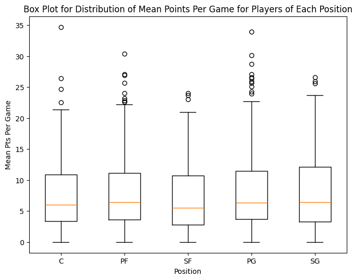

```python
plt.figure(figsize=(8,6))

plt.boxplot([data for _,data in merged_positions_data.items()], tick_labels=[position for position,_ in merged_positions_data.items()])

plt.title("Box Plot for Distribution of Mean Points Per Game for Players of Each Position")
plt.xlabel("Position")
plt.ylabel("Mean Pts Per Game")
plt.show()
```

Perform the Anova Test

```python
anova_result = stats.f_oneway(*merged_positions_data.values())

print(f"P-value: {anova_result.pvalue}")
```

```
P-value: 0.34466212423934145
```

The P-value of 0.34466212423934145 is significantly higher than the standard significance level of 0.05. Given the P-value, we see that assuming the null hypothesis is true, the given data is very likely. Additionally, the P-value is greater than alpha, so we fail to reject the null hypothesis. There is no significant difference between the mean points per game of players in each specific position (PG, SG, SF, PF, C).

## 4. Primary Analysis

We want to apply machine learning to the problem at hand of determining whether certain game statistics are indicative of a player role. There are many machine learning techniques to choose from so deciding which one would best fit our needs is crucial. Our question relates to game statistics indicating a specific player role meaning that we want our model to take in game statistics data and give us a prediction of what role it likely corresponds to. This is clearly a classification problem.

However, there are multiple classification models out there we aren’t sure which one might best fit our needs. Therefore, we decided to create multiple models and use k-fold cross validation in order to determine which classification model would be best for us to use.

Get the original dataframe

```python
player_df_23_24 = pd.read_csv("regular_season_2023-24.csv", encoding='ISO-8859-1', delimiter=";")
player_df_23_24
```

|  | Rk | Player | Pos | Age | Tm | G | GS | MP | FG | FGA | ... | FT% | ORB | DRB | TRB | AST | STL | BLK | TOV | PF | PTS |
| --- | --- | --- | --- | --- | --- | --- | --- | --- | --- | --- | --- | --- | --- | --- | --- | --- | --- | --- | --- | --- | --- |
| 0 | 1 | Precious Achiuwa | PF-C | 24 | TOT | 74 | 18 | 21.9 | 3.2 | 6.3 | ... | 0.616 | 2.6 | 4.0 | 6.6 | 1.3 | 0.6 | 0.9 | 1.1 | 1.9 | 7.6 |
| 1 | 1 | Precious Achiuwa | C | 24 | TOR | 25 | 0 | 17.5 | 3.1 | 6.8 | ... | 0.571 | 2.0 | 3.4 | 5.4 | 1.8 | 0.6 | 0.5 | 1.2 | 1.6 | 7.7 |
| 2 | 1 | Precious Achiuwa | PF | 24 | NYK | 49 | 18 | 24.2 | 3.2 | 6.1 | ... | 0.643 | 2.9 | 4.3 | 7.2 | 1.1 | 0.6 | 1.1 | 1.1 | 2.1 | 7.6 |
| 3 | 2 | Bam Adebayo | C | 26 | MIA | 71 | 71 | 34.0 | 7.5 | 14.3 | ... | 0.755 | 2.2 | 8.1 | 10.4 | 3.9 | 1.1 | 0.9 | 2.3 | 2.2 | 19.3 |
| 4 | 3 | Ochai Agbaji | SG | 23 | TOT | 78 | 28 | 21.0 | 2.3 | 5.6 | ... | 0.661 | 0.9 | 1.8 | 2.8 | 1.1 | 0.6 | 0.6 | 0.8 | 1.5 | 5.8 |
| ... | ... | ... | ... | ... | ... | ... | ... | ... | ... | ... | ... | ... | ... | ... | ... | ... | ... | ... | ... | ... | ... |
| 730 | 568 | Thaddeus Young | PF | 35 | PHO | 10 | 0 | 8.9 | 1.1 | 2.1 | ... | 0.333 | 1.7 | 1.1 | 2.8 | 0.7 | 0.5 | 0.2 | 0.4 | 1.1 | 2.3 |
| 731 | 569 | Trae Young | PG | 25 | ATL | 54 | 54 | 36.0 | 8.0 | 18.7 | ... | 0.855 | 0.4 | 2.3 | 2.8 | 10.8 | 1.3 | 0.2 | 4.4 | 2.0 | 25.7 |
| 732 | 570 | Omer Yurtseven | C | 25 | UTA | 48 | 12 | 11.4 | 2.1 | 3.8 | ... | 0.679 | 1.5 | 2.8 | 4.3 | 0.6 | 0.2 | 0.4 | 0.8 | 1.1 | 4.6 |
| 733 | 571 | Cody Zeller | C | 31 | NOP | 43 | 0 | 7.4 | 0.6 | 1.4 | ... | 0.605 | 1.1 | 1.5 | 2.6 | 0.9 | 0.2 | 0.1 | 0.4 | 1.0 | 1.8 |
| 734 | 572 | Ivica Zubac | C | 26 | LAC | 68 | 68 | 26.4 | 5.0 | 7.6 | ... | 0.723 | 2.9 | 6.3 | 9.2 | 1.4 | 0.3 | 1.2 | 1.2 | 2.6 | 11.7 |

735 rows × 30 columns

To help our future model, let's include some data from past years as well. Luckily, some datasets with the same format already exist. Let's concatenate these together.

```python
player_df_21_22 = pd.read_csv("regular_season_2021-22.csv", encoding='ISO-8859-1', delimiter=";")
player_df_22_23 = pd.read_csv("regular_season_2022-23.csv", encoding='ISO-8859-1', delimiter=";")

df = pd.concat([player_df_23_24, player_df_21_22, player_df_22_23], ignore_index=True)
df
```

|  | Rk | Player | Pos | Age | Tm | G | GS | MP | FG | FGA | ... | FT% | ORB | DRB | TRB | AST | STL | BLK | TOV | PF | PTS |
| --- | --- | --- | --- | --- | --- | --- | --- | --- | --- | --- | --- | --- | --- | --- | --- | --- | --- | --- | --- | --- | --- |
| 0 | 1 | Precious Achiuwa | PF-C | 24 | TOT | 74 | 18 | 21.9 | 3.2 | 6.3 | ... | 0.616 | 2.6 | 4.0 | 6.6 | 1.3 | 0.6 | 0.9 | 1.1 | 1.9 | 7.6 |
| 1 | 1 | Precious Achiuwa | C | 24 | TOR | 25 | 0 | 17.5 | 3.1 | 6.8 | ... | 0.571 | 2.0 | 3.4 | 5.4 | 1.8 | 0.6 | 0.5 | 1.2 | 1.6 | 7.7 |
| 2 | 1 | Precious Achiuwa | PF | 24 | NYK | 49 | 18 | 24.2 | 3.2 | 6.1 | ... | 0.643 | 2.9 | 4.3 | 7.2 | 1.1 | 0.6 | 1.1 | 1.1 | 2.1 | 7.6 |
| 3 | 2 | Bam Adebayo | C | 26 | MIA | 71 | 71 | 34.0 | 7.5 | 14.3 | ... | 0.755 | 2.2 | 8.1 | 10.4 | 3.9 | 1.1 | 0.9 | 2.3 | 2.2 | 19.3 |
| 4 | 3 | Ochai Agbaji | SG | 23 | TOT | 78 | 28 | 21.0 | 2.3 | 5.6 | ... | 0.661 | 0.9 | 1.8 | 2.8 | 1.1 | 0.6 | 0.6 | 0.8 | 1.5 | 5.8 |
| ... | ... | ... | ... | ... | ... | ... | ... | ... | ... | ... | ... | ... | ... | ... | ... | ... | ... | ... | ... | ... | ... |
| 2221 | 535 | Thaddeus Young | PF | 34 | TOR | 54 | 9 | 14.7 | 2.0 | 3.7 | ... | 0.692 | 1.3 | 1.8 | 3.1 | 1.4 | 1.0 | 0.1 | 0.8 | 1.6 | 4.4 |
| 2222 | 536 | Trae Young | PG | 24 | ATL | 73 | 73 | 34.8 | 8.2 | 19.0 | ... | 0.886 | 0.8 | 2.2 | 3.0 | 10.2 | 1.1 | 0.1 | 4.1 | 1.4 | 26.2 |
| 2223 | 537 | Omer Yurtseven | C | 24 | MIA | 9 | 0 | 9.2 | 1.8 | 3.0 | ... | 0.833 | 0.9 | 1.7 | 2.6 | 0.2 | 0.2 | 0.2 | 0.4 | 1.8 | 4.4 |
| 2224 | 538 | Cody Zeller | C | 30 | MIA | 15 | 2 | 14.5 | 2.5 | 3.9 | ... | 0.686 | 1.7 | 2.6 | 4.3 | 0.7 | 0.2 | 0.3 | 0.9 | 2.2 | 6.5 |
| 2225 | 539 | Ivica Zubac | C | 25 | LAC | 76 | 76 | 28.6 | 4.3 | 6.8 | ... | 0.697 | 3.1 | 6.8 | 9.9 | 1.0 | 0.4 | 1.3 | 1.5 | 2.9 | 10.8 |

2226 rows × 30 columns

```python
df = df[~df['Pos'].str.contains('-')]
df
```

|  | Rk | Player | Pos | Age | Tm | G | GS | MP | FG | FGA | ... | FT% | ORB | DRB | TRB | AST | STL | BLK | TOV | PF | PTS |
| --- | --- | --- | --- | --- | --- | --- | --- | --- | --- | --- | --- | --- | --- | --- | --- | --- | --- | --- | --- | --- | --- |
| 1 | 1 | Precious Achiuwa | C | 24 | TOR | 25 | 0 | 17.5 | 3.1 | 6.8 | ... | 0.571 | 2.0 | 3.4 | 5.4 | 1.8 | 0.6 | 0.5 | 1.2 | 1.6 | 7.7 |
| 2 | 1 | Precious Achiuwa | PF | 24 | NYK | 49 | 18 | 24.2 | 3.2 | 6.1 | ... | 0.643 | 2.9 | 4.3 | 7.2 | 1.1 | 0.6 | 1.1 | 1.1 | 2.1 | 7.6 |
| 3 | 2 | Bam Adebayo | C | 26 | MIA | 71 | 71 | 34.0 | 7.5 | 14.3 | ... | 0.755 | 2.2 | 8.1 | 10.4 | 3.9 | 1.1 | 0.9 | 2.3 | 2.2 | 19.3 |
| 4 | 3 | Ochai Agbaji | SG | 23 | TOT | 78 | 28 | 21.0 | 2.3 | 5.6 | ... | 0.661 | 0.9 | 1.8 | 2.8 | 1.1 | 0.6 | 0.6 | 0.8 | 1.5 | 5.8 |
| 5 | 3 | Ochai Agbaji | SG | 23 | UTA | 51 | 10 | 19.7 | 2.1 | 4.9 | ... | 0.750 | 0.7 | 1.8 | 2.5 | 0.9 | 0.5 | 0.6 | 0.7 | 1.3 | 5.4 |
| ... | ... | ... | ... | ... | ... | ... | ... | ... | ... | ... | ... | ... | ... | ... | ... | ... | ... | ... | ... | ... | ... |
| 2221 | 535 | Thaddeus Young | PF | 34 | TOR | 54 | 9 | 14.7 | 2.0 | 3.7 | ... | 0.692 | 1.3 | 1.8 | 3.1 | 1.4 | 1.0 | 0.1 | 0.8 | 1.6 | 4.4 |
| 2222 | 536 | Trae Young | PG | 24 | ATL | 73 | 73 | 34.8 | 8.2 | 19.0 | ... | 0.886 | 0.8 | 2.2 | 3.0 | 10.2 | 1.1 | 0.1 | 4.1 | 1.4 | 26.2 |
| 2223 | 537 | Omer Yurtseven | C | 24 | MIA | 9 | 0 | 9.2 | 1.8 | 3.0 | ... | 0.833 | 0.9 | 1.7 | 2.6 | 0.2 | 0.2 | 0.2 | 0.4 | 1.8 | 4.4 |
| 2224 | 538 | Cody Zeller | C | 30 | MIA | 15 | 2 | 14.5 | 2.5 | 3.9 | ... | 0.686 | 1.7 | 2.6 | 4.3 | 0.7 | 0.2 | 0.3 | 0.9 | 2.2 | 6.5 |
| 2225 | 539 | Ivica Zubac | C | 25 | LAC | 76 | 76 | 28.6 | 4.3 | 6.8 | ... | 0.697 | 3.1 | 6.8 | 9.9 | 1.0 | 0.4 | 1.3 | 1.5 | 2.9 | 10.8 |

2190 rows × 30 columns

Drop the unnecessary columns

```python
cols_to_drop = ['Player', 'Rk', 'Age', 'Tm', 'GS', 'G', 'MP']
repeats = ['FG', 'FG%', '3P', '3P%', '2P', '2P%', 'eFG%', 'FT', 'FT%']
df = df.drop(cols_to_drop, axis=1)
df = df.drop(repeats, axis=1)
df
```

|  | Pos | FGA | 3PA | 2PA | FTA | ORB | DRB | TRB | AST | STL | BLK | TOV | PF | PTS |
| --- | --- | --- | --- | --- | --- | --- | --- | --- | --- | --- | --- | --- | --- | --- |
| 1 | C | 6.8 | 1.9 | 4.9 | 1.7 | 2.0 | 3.4 | 5.4 | 1.8 | 0.6 | 0.5 | 1.2 | 1.6 | 7.7 |
| 2 | PF | 6.1 | 1.0 | 5.1 | 1.4 | 2.9 | 4.3 | 7.2 | 1.1 | 0.6 | 1.1 | 1.1 | 2.1 | 7.6 |
| 3 | C | 14.3 | 0.6 | 13.7 | 5.5 | 2.2 | 8.1 | 10.4 | 3.9 | 1.1 | 0.9 | 2.3 | 2.2 | 19.3 |
| 4 | SG | 5.6 | 2.7 | 2.8 | 0.7 | 0.9 | 1.8 | 2.8 | 1.1 | 0.6 | 0.6 | 0.8 | 1.5 | 5.8 |
| 5 | SG | 4.9 | 2.8 | 2.1 | 0.4 | 0.7 | 1.8 | 2.5 | 0.9 | 0.5 | 0.6 | 0.7 | 1.3 | 5.4 |
| ... | ... | ... | ... | ... | ... | ... | ... | ... | ... | ... | ... | ... | ... | ... |
| 2221 | PF | 3.7 | 0.6 | 3.0 | 0.5 | 1.3 | 1.8 | 3.1 | 1.4 | 1.0 | 0.1 | 0.8 | 1.6 | 4.4 |
| 2222 | PG | 19.0 | 6.3 | 12.7 | 8.8 | 0.8 | 2.2 | 3.0 | 10.2 | 1.1 | 0.1 | 4.1 | 1.4 | 26.2 |
| 2223 | C | 3.0 | 0.8 | 2.2 | 0.7 | 0.9 | 1.7 | 2.6 | 0.2 | 0.2 | 0.2 | 0.4 | 1.8 | 4.4 |
| 2224 | C | 3.9 | 0.1 | 3.8 | 2.3 | 1.7 | 2.6 | 4.3 | 0.7 | 0.2 | 0.3 | 0.9 | 2.2 | 6.5 |
| 2225 | C | 6.8 | 0.0 | 6.7 | 3.1 | 3.1 | 6.8 | 9.9 | 1.0 | 0.4 | 1.3 | 1.5 | 2.9 | 10.8 |

2190 rows × 14 columns

Get our Labels (y) and Features (X)

```python
X = df.drop(['Pos'], axis=1)
y = df['Pos']
y
```

```
1        C
2       PF
3        C
4       SG
5       SG
        ..
2221    PF
2222    PG
2223     C
2224     C
2225     C
Name: Pos, Length: 2190, dtype: object
```

As we can see, our labels are strings, but many models work better with numbers, so let's convert it into numbers, and keep a dictionary of the mappings

```python
unique_pos = y.drop_duplicates()

pos_map = dict()
i = 1
for pos in unique_pos:
    pos_map[pos] = i
    i += 1

print(pos_map)
y = y.apply(lambda x : pos_map[x])
y
```

```
{'C': 1, 'PF': 2, 'SG': 3, 'SF': 4, 'PG': 5}
```

```
1       1
2       2
3       1
4       3
5       3
       ..
2221    2
2222    5
2223    1
2224    1
2225    1
Name: Pos, Length: 2190, dtype: int64
```

Let's split our data into training and testing.

```python
from sklearn.model_selection import train_test_split, cross_val_score, StratifiedKFold
test_size = 0.2
random_state = 42

X_train, X_test, y_train, y_test = train_test_split(X, y, random_state=random_state, test_size=test_size)
X_train
```

|  | FGA | 3PA | 2PA | FTA | ORB | DRB | TRB | AST | STL | BLK | TOV | PF | PTS |
| --- | --- | --- | --- | --- | --- | --- | --- | --- | --- | --- | --- | --- | --- |
| 166 | 3.5 | 2.1 | 1.4 | 0.5 | 0.3 | 1.2 | 1.5 | 1.1 | 0.2 | 0.2 | 0.6 | 0.7 | 4.0 |
| 1907 | 18.0 | 7.1 | 11.0 | 5.6 | 0.5 | 3.9 | 4.5 | 4.2 | 0.9 | 0.2 | 2.5 | 2.1 | 24.8 |
| 1396 | 2.6 | 1.2 | 1.4 | 0.6 | 0.1 | 0.8 | 0.9 | 0.4 | 0.2 | 0.2 | 0.4 | 0.5 | 2.7 |
| 564 | 6.3 | 2.5 | 3.8 | 1.0 | 0.8 | 2.4 | 3.2 | 1.2 | 0.4 | 0.2 | 0.9 | 1.1 | 6.5 |
| 980 | 4.3 | 2.7 | 1.7 | 0.0 | 0.7 | 2.7 | 3.3 | 2.3 | 0.3 | 0.0 | 0.3 | 0.7 | 0.7 |
| ... | ... | ... | ... | ... | ... | ... | ... | ... | ... | ... | ... | ... | ... |
| 1669 | 16.9 | 7.5 | 9.4 | 4.0 | 1.2 | 2.9 | 4.0 | 4.4 | 0.5 | 0.2 | 3.0 | 2.0 | 20.8 |
| 1119 | 7.4 | 2.7 | 4.6 | 1.4 | 0.6 | 1.5 | 2.2 | 2.1 | 0.8 | 0.3 | 1.2 | 1.9 | 7.2 |
| 1154 | 5.0 | 3.4 | 1.6 | 1.6 | 0.0 | 1.6 | 1.6 | 1.6 | 0.2 | 0.0 | 0.8 | 1.0 | 6.4 |
| 1321 | 1.7 | 0.0 | 1.7 | 0.0 | 1.0 | 1.0 | 2.0 | 0.0 | 0.0 | 0.3 | 0.7 | 0.3 | 2.0 |
| 875 | 1.9 | 0.0 | 1.9 | 1.6 | 0.8 | 1.9 | 2.7 | 0.2 | 0.2 | 0.2 | 0.4 | 1.4 | 3.4 |

1752 rows × 13 columns

Let's normalize our data!

```python
from sklearn.preprocessing import StandardScaler
scaler = StandardScaler()
scaler.fit(X_train)
X_train_scaled = scaler.transform(X_train)

X_test_scaled = scaler.transform(X_test)
```

Now That we've done our preprocessing, let's create our model! We want to see if we can correctly predict a player's position based on their game stats, to see if there is a significant relationship between the two. This looks like a job for a classification model, but which one do we choose?

```python
from sklearn.tree import DecisionTreeClassifier
from sklearn.neighbors import KNeighborsClassifier
from sklearn.ensemble import RandomForestClassifier
from sklearn.linear_model import LogisticRegression

models = {
            "KNN":KNeighborsClassifier(),
            "DecisionTree":DecisionTreeClassifier(),
            "Logistic Regression":LogisticRegression(),
            "Random Forest":RandomForestClassifier()
         }
```

```python
k_folds = 5
seed = 42
skf = StratifiedKFold(n_splits=k_folds, shuffle=True, random_state=seed)

for model_name, model in models.items():
    np.random.seed(seed)
    scores = cross_val_score(model, X_train_scaled, y_train, cv=skf)
    print(f"Cross Validation Accuracy for {model_name}: Mean: {scores.mean()}, Standard Deviation: {scores.std()}")
```

```
Cross Validation Accuracy for KNN: Mean: 0.48745299145299137, Standard Deviation: 0.015876568359443982
Cross Validation Accuracy for DecisionTree: Mean: 0.45090923890923895, Standard Deviation: 0.018396577161909764
Cross Validation Accuracy for Logistic Regression: Mean: 0.5274106634106634, Standard Deviation: 0.023230788954001436
Cross Validation Accuracy for Random Forest: Mean: 0.5313976393976395, Standard Deviation: 0.027215339978490353
```

It seems like Random Forest has the highest mean accuracy

```python
model = RandomForestClassifier(n_estimators=100)
```

Perform our training and evaluation!

```python
from sklearn.metrics import accuracy_score, classification_report

seed = 46
np.random.seed(seed)
model.fit(X_train_scaled, y_train)

y_pred = model.predict(X_test_scaled)

accuracy = accuracy_score(y_test, y_pred)
print(accuracy)

print(classification_report(y_test, y_pred))
```

```
0.6484018264840182
              precision    recall  f1-score   support

           1       0.88      0.80      0.84        82
           2       0.61      0.54      0.57        80
           3       0.57      0.64      0.61       104
           4       0.52      0.52      0.52        87
           5       0.71      0.74      0.72        85

    accuracy                           0.65       438
   macro avg       0.66      0.65      0.65       438
weighted avg       0.65      0.65      0.65       438
```

## 5. Visualization

Let's plot the importances of each feature that our random forest classifier found.

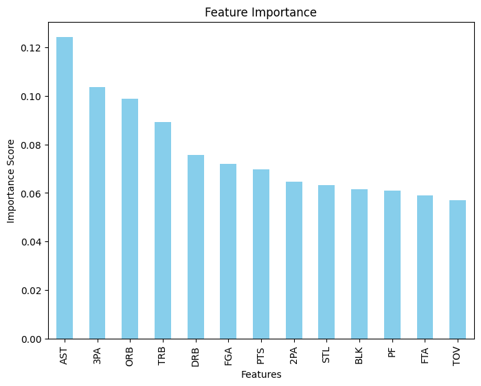

```python
import matplotlib.pyplot as plt
importances = model.feature_importances_
indices = pd.Series(importances, index=X.columns).sort_values(ascending=False)

plt.figure(figsize=(8, 6))
indices.plot(kind="bar", color="skyblue")
plt.title("Feature Importance")
plt.ylabel("Importance Score")
plt.xlabel("Features")
plt.show()
```

Let's look at our decision trees in the random forest

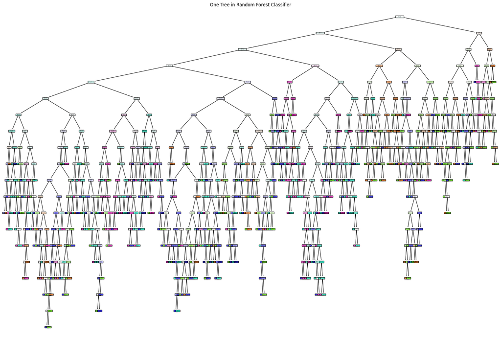

```python
from sklearn.tree import plot_tree
tree = model.estimators_[0]

plt.figure(figsize=(24, 16))
plot_tree(tree, feature_names=X.columns, class_names = ['C', 'PF', 'SG', 'SF', 'PG'], filled=True)
plt.title("One Tree in Random Forest Classifier")
plt.show()
```

For additional information on plotting trees: https://scikit-learn.org/1.5/modules/generated/sklearn.tree.plot_tree.html

After creating a bar graph, we also wanted to experiment with displaying the decision trees involved with a random forest. The tree we plotted was quite complicated and difficult to read, but it shows that we used a lot of different features in determining player position. Also, classification tasks often create large decision trees when there are multiple different categories (in our case each of the 5 positions).

## 6. Insights and Conclusions

The classification of player roles based on game statistics is more complicated than we originally thought. Although the accuracy of our model wasn’t very high, we were still able to identify the most important/contributing features to the model’s decision making. The top three features were: Assists, 3 Point Attempts, and Offensive Rebounds.

Our data has shown that there are certain correlations between specific game stats and the position that a player plays. Through our exploratory analysis we found that there wasn’t much of a correlation between the role of a player and their points per game, which implies there may be other factors that determine whether or not a player is a good fit for a certain role.

We applied machine learning to find a relationship between the game statistics and player role so that it could be used as a classifier for future targets. This could be used to identify potential role changes for players who have specific game statistics that might be better suited to a role other than the one they currently play. This could also help to identify weaknesses and strengths of players as well as help coaches identify various possible lineups for their team.

Using the Random Forest Model, we were able to find those relationships between game statistics and player roles. While this predictor is not entirely accurate and is not an absolute indicator of role suitability for players, this could be one point that coaches consider when looking at players and their overall team composition.